# Solução de exercícios de final de capítulo

O livro **Visualização de Dados com o R** está disponível na Amazon no formato ebook e impresso. Uma versão online do livro é disponível em https://www.msperlin.com/vdr

## Questões

#### Question

1. O grupo [LatinoMetrics](https://latinometrics.substack.com/) produz e distribui um conteúdo muito interessante de visualização de dados econômicos para a América Latina. Observando o material do [Instagram](https://www.instagram.com/latinometrics/), visualize as seis últimas imagens disponibilizadas na página principal. Observando as figuras como um todo, destaque os elementos comuns na criação das imagens. Isto, é, destaque os elementos visuais que foram repetidos entre uma figura e outra.

#### Solution

   Em um acesso do dia 27/09/2022, observa-se as seis últimas publicações da página do LatinoMetrics do [Instagram](https://www.instagram.com/latinometrics/).

[figure not shown]

   Seis últimas publicações do LatinoMetrics em 27/09/2022

   Nota-se os seguintes elementos repetidos entre uma figura e outra:
   - Todos gráficos possuem a mesma cor de fundo, e logo do LatinoMetrics em algum lugar.
   - A paleta de cores dos interior do gráfico tende a ser relacionada ao tema. Veja, por exemplo, que o primeiro gráfico – “A Mexican Abuelita has One of the Hottest coking Channels” – usa o vermelho e azul para distinguir canais individuais e corporativos do Youtube.
   - A origem dos dados é sempre definida no *caption*, texto abaixo e esquerda do gráfico.
   - Todas legendas sempre ficam abaixo do título ou no interior do gráfico.
   - Sempre que possível, observa-se o uso expressivo de símbolos e logos. Por exemplo, o logo de empresas é utilizado ostensivamente ao longo de diferentes figuras.

#### Question

2. No Reddit é possível encontrar o grupo [r/dataisugly](https://www.reddit.com/r/dataisugly/), o qual contém inúmeros posts sobre visualizações de dados realizadas da forma errada. Na data de 27/09/2022 foi publicado a seguinte [mensagem](https://www.reddit.com/r/dataisugly/comments/xphz87/polls_for_upcoming_s%C3%A3o_paulo_state_governor/) no fórum:

[figure not shown]

   Publicação do reddit/dataisuglu em 27/09/2022

   Analise o gráfico e, sem buscar a resposta no fórum, indique qual o problema com o gráfico.

#### Solution

   O problema do gráfico é a escala errada para o eixo vertical. Note que o valor de 20% é compartilhado pelo candidatos **Garcia** e **Tarcísio**, porém em localizações muito diferentes! É impossível de dizer se foi erro do programador ou alguma intenção política. Porém, o visual do gráfico indica, para os mesmos pontos de dados, mais peso visual para um candidato do que para o outro.

#### Question

3. Em 22/09/2022, o grupo [LatinoMetrics](https://latinometrics.substack.com/) publicou uma visualização de dados a respeito da impressão de confiança da população brasileira em relação as diferens mídias jornalísticas. O conteúdo pode ser acessado no Instagram, e é disponilizado abaixo:

[figure not shown]

   Postagem do LatinoMetrics em 22/09/2022

   Observando a figura, destaque os elementos **textuais** e **gráficos** utilizados pelo autor.

#### Solution

   Os elementos textuais são:
   - título com fonte maior, e *caption* com origem dos dados. Nota-se também que eixos *x* e *y* não possuem texto algum.

   Os elementos gráficos:
   - Uso de barras horizontais com a percentagem de respostas dos entrevistados.
   - Ordenamento das barras, de forma que a mídia com maior percentagem de confiança, o SBT, fique acima das demais.
   - uso de logos das mídias jornalísticas no lado esquerdo do gráfico.
   - uso de cores para direcionar a interpretação do gráfico. A cor vermelha indica a “não confiança” na emissora, enquanto a azul indica confiança.

#### Question

4. [Statspanda](https://www.instagram.com/statspanda/?hl=en) é outro grupo especializado em produção de conteúdo relacionado a visualização de dados, porém com assuntos muito mais abrangentes que o LatinoMetrics. Em 17/09/2022, o grupo publicou a seguinte figura no [Instagram](https://www.instagram.com/p/CaFZoVpO3gc/?hl=en):

[figure not shown]

   Neste caso, quais foram os elementos **gráficos** utilizados pelo autor e como os mesmos se associam a mensagem da figura.

#### Solution

   Os elementos textuais são:
   - título e subtítulo com a mensagem do gráfico;
   - textos nos eixos verticais e horizontais;
   - o número de mortes acima de cada barra do gráfico, sendo usando uma escala padronizada de milhões (1m);

   Os elementos gráficos são:
   - uso de barras verticais para indicar a mortalidade das diferentes doenças;
   - uso de logos para as doenças de maior mortalidade;
   - uso de cores sugestivas, com cor preta para a doença mais mortífera;
   - Realçe do caso da COVID, com cor vermelha.

#### Question

5. No [Reddit/dataisbeautiful](https://www.reddit.com/r/dataisbeautiful/comments/xoqi8w/revenue_and_budget_comparison_for_every_star_wars/) é possível encontrar a visualização da receita de todos os filmes da franchise *Star Wars*.

[figure not shown]

   Postagem do Reddit/dataisbeautiful

   Apesar de ser esteticamante interessante, o mesmo poderia ser melhorado. Com base no que aprendeu neste capítulo do livro, analise o gráfico e faça recomendações para sua melhoria buscando sempre maior claridade e simplicidade.

#### Solution

   Assumindo que a mensagem do gráfico é o faturamente ano a ano de todos os filmes relacionados a *franchise*, as mudanças que certamente melhorariam o gráfico são:
   1. modificar o gráfico para um com o tempo no eixo horizontal, o qual é mais intuitivo ao mostrar o tempo evoluindo para a direita;
   2. usar barras verticais para cada filme, adicionando um texto com o “budget” de cada filme no topo de cada barra;
   3. remover as “espadas de laser” e outros elementos visuais desnecessários, as quais não tem finalidade alguma na interpretação do gráfico e não adicionam informação relevante;
   4. usar cores para ressaltar os filmes com maiores faturamentos, possivelmente com uma paleta de cores de intensidade;

#### Question

6. Em um novo script do R, crie um vetor de valores aleatórios da distribuição Normal com o comando `rnorm(N)`, onde N é igual a 100. Agora, crie um gráfico de pontos onde o eixo *y* é representado pela série anterior, e o eixo *x* é simplesmente a contagem dos valores (1..100). Para este gráfico, utilize o *template* básico do `ggplot2`, isto é, não precisas modificar nenhum elemento textual do gráfico, por enquanto.

#### Solution

   ```
   require(ggplot2)

   N <- 100
   vec <- rnorm(N)
   df <- dplyr::tibble(
     y = vec,
     x = 1:N
     )

   p <- ggplot(df, aes(x = x, y = y)) +
     geom_point()

   p
   ```

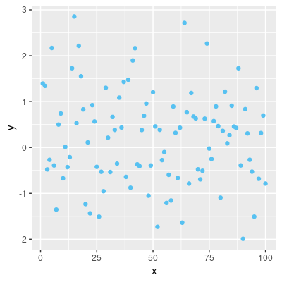

#### Question

7. Para o gráfico anterior, adicione os seguintes elementos textuais e gráficos:
   - título, subtítulo;
   - *caption* com a data e tempo de compilação do gráfico;
   - textos nos eixos *x* e *y*;
   - aplique o tema `theme_light`

#### Solution

   ```
   require(ggplot2)

   N <- 100
   vec <- rnorm(N)
   df <- dplyr::tibble(
     y = vec,
     x = 1:N
     )

   p <- ggplot(df, aes(x = x, y = y)) +
     geom_point() +
     labs(title = "TÍTULO",
          subtitle = "SUBTÍTULO",
          caption = stringr::str_glue("Compilado em {Sys.time()}"),
          x = "texto X",
          y = "texto Y") +
     theme_light()

   p
   ```

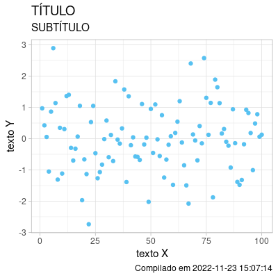

#### Question

8. Para o mesmo gráfico anterior, adicione uma nova coluna chamada `type` no dataframe, a qual pode tomar o valor “A” ou “B”. Para isto, podes usar o comando `sample(c("A", "B"), size = N, replace = TRUE)`. Note que o valor de N foi definido anteriormente.

#### Solution

   ```
   require(ggplot2)

   N <- 100
   vec <- rnorm(N)
   df <- dplyr::tibble(
     y = vec,
     x = 1:N,
     type = sample(c("A", "B"), size = N, replace = TRUE)
     )

   p <- ggplot(df, aes(x = x, y = y, color = type)) +
     geom_point() +
     labs(title = "TÍTULO",
          subtitle = "SUBTÍTULO",
          caption = "CAPTION",
          x = "texto X",
          y = "texto Y") +
     theme_light()

   p
   ```

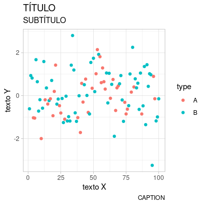

#### Question

9. Para o mesmo gráfico anterior, adicione uma camada de linhas no gráfico.

#### Solution

   ```
   require(ggplot2)

   N <- 100
   vec <- rnorm(N)
   df <- dplyr::tibble(
     y = vec,
     x = 1:N,
     type = sample(c("A", "B"), size = N, replace = TRUE)
     )

   p <- ggplot(df, aes(x = x, y = y, color = type)) +
     geom_point() +
     labs(title = "TÍTULO",
          subtitle = "SUBTÍTULO",
          caption = "CAPTION",
          x = "texto X",
          y = "texto Y") +
     theme_light() +
     geom_line()

   p
   ```

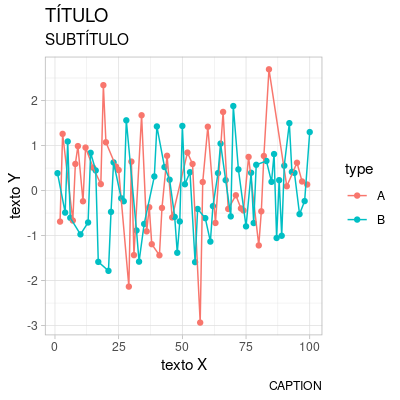

#### Question

10. Agora, use o gráfico anterior, mas modifique o formato dos pontos, definindo que o argumento `shape` será mapeado de acordo com coluna `type`. Também aumente o tamanho de todos os pontos do gráfico para 3.

#### Solution

    ```
    require(ggplot2)

    N <- 100
    vec <- rnorm(N)
    df <- dplyr::tibble(
      y = vec,
      x = 1:N,
      type = sample(c("A", "B"), size = N, replace = TRUE)
      )

    p <- ggplot(df, aes(x = x, y = y,
                        color = type,
                        shape = type)) +
      geom_point(size = 3) +
      labs(title = "TÍTULO",
           subtitle = "SUBTÍTULO",
           caption = "CAPTION",
           x = "texto X",
           y = "texto Y") +
      theme_light() +
      geom_line()

    p
    ```

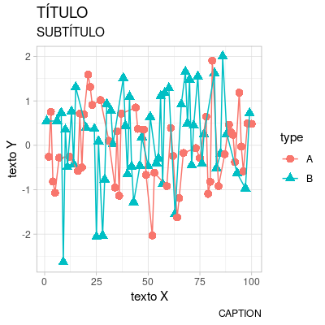

#### Question

11. Agora, modifique o código para que o tamanho dos pontos seja relativo a coluna `x` do dataframe de entrada. Isto é, o efeito desejado é que os pontos aumentem de tamanho ao longo do eixo horizontal.

#### Solution

    ```
    require(ggplot2)

    N <- 100
    vec <- rnorm(N)
    df <- dplyr::tibble(
      y = vec,
      x = 1:N,
      type = sample(c("A", "B"), size = N, replace = TRUE)
      )

    p <- ggplot(df, aes(x = x, y = y,
                        color = type,
                        shape = type)) +
      geom_point(aes(size = x)) +
      labs(title = "TÍTULO",
           subtitle = "SUBTÍTULO",
           caption = "CAPTION",
           x = "texto X",
           y = "texto Y") +
      geom_line()

    p
    ```

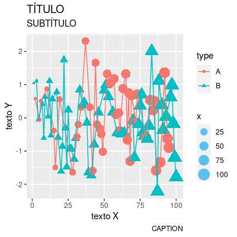

#### Question

12. Neste exercício, remova a camada de pontos utilizada no gráfico e adicione o texto disponível na coluna `type` (A ou B) no mesmo local onde os pontos se situavam.

#### Solution

    ```
    require(ggplot2)

    N <- 100
    vec <- rnorm(N)
    df <- dplyr::tibble(
      y = vec,
      x = 1:N,
      type = sample(c("A", "B"), size = N, replace = TRUE)
      )

    p <- ggplot(df, aes(x = x, y = y,
                        color = type,
                        label = type)) +
      #geom_point(aes(size = x)) +
      labs(title = "TÍTULO",
           subtitle = "SUBTÍTULO",
           caption = "CAPTION",
           x = "texto X",
           y = "texto Y") +
      geom_line() +
      geom_text()

    p
    ```

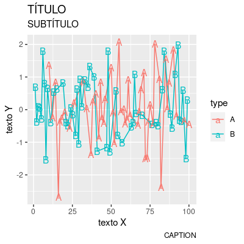

#### Question

13. Para o gráfico anterior, use as funções do pacote `colorspace` para implementar a paleta de cores “Harmonic” do canal `color` (dados qualitativos).

#### Solution

    ```
    require(ggplot2)

    N <- 100
    vec <- rnorm(N)
    df <- dplyr::tibble(
      y = vec,
      x = 1:N,
      type = sample(c("A", "B"), size = N, replace = TRUE)
      )

    p <- ggplot(df, aes(x = x, y = y,
                        color = type,
                        label = type)) +
      #geom_point(aes(size = x)) +
      labs(title = "TÍTULO",
           subtitle = "SUBTÍTULO",
           caption = "CAPTION",
           x = "texto X",
           y = "texto Y") +
      geom_line() +
      geom_text() +
      colorspace::scale_colour_discrete_qualitative("Harmonic")

    p
    ```

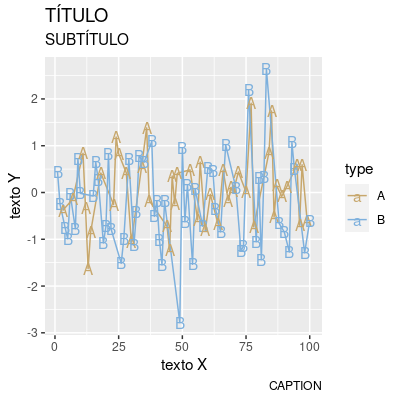

#### Question

14. Exporte a figura anterior com as seguintes informações:
    1. arquivo de exportação chamado “fig-eoc-vdr.png” e localizado na pasta padrão “Documentos” (atalho com `~`);
    2. use um tamanho 10 X 10 em centímetros

    Verifique se o arquivo foi criado corretamente na pasta desejada.

#### Solution

    ```
    require(ggplot2)

    N <- 100
    vec <- rnorm(N)
    df <- dplyr::tibble(
      y = vec,
      x = 1:N,
      type = sample(c("A", "B"), size = N, replace = TRUE)
      )

    p <- ggplot(df, aes(x = x, y = y,
                        color = type,
                        label = type)) +
      #geom_point(aes(size = x)) +
      labs(title = "TÍTULO",
           subtitle = "SUBTÍTULO",
           caption = "CAPTION",
           x = "texto X",
           y = "texto Y") +
      geom_line() +
      geom_text() +
      colorspace::scale_colour_discrete_qualitative("Harmonic")

    f_png <- "~/fig-eoc-vdr.png"
    ggsave(filename = f_png, plot = p,
           height = 10, width = 10, units = "cm")

    fs::file_exists(f_png)
    ```

    ```
    ## ~/fig-eoc-vdr.png
    ##              TRUE
    ```

    ```
    library(ggplot2)

    df_ibov <- yfR::yf_collection_get("IBOV",
                                      first_date = Sys.Date() - 5*365)

    # passo 01
    df_tab <- df_ibov |>
      dplyr::group_by(ticker ) |>
      dplyr::summarize(final_ret = dplyr::last(cumret_adjusted_prices)) |>
      dplyr::arrange(final_ret)

    n_selected <- 5
    selected <- dplyr::bind_rows(
      head(df_tab, n_selected),
      tail(df_tab, n_selected)
    )

    df_ibov <- df_ibov |>
      dplyr::filter(ticker %in% selected$ticker)

    p <- ggplot(df_ibov, aes(x = ref_date, y = cumret_adjusted_prices,
                             color = ticker)) +
      # passo 02
      geom_line() +
      # passo 03
      labs(title = "Retornos acumulados para 10 ações do Ibovespa",
           subtitle = stringr::str_glue("Dados entre {min(df_ibov$ref_date)} e {max(df_ibov$ref_date)}"),
           caption = stringr::str_glue("Compilado em {Sys.time()}"),
           x = "Dias",
           y = "Retorno Acumulado") +
      scale_y_continuous(labels = scales::percent) +
      theme_light()

    p

    # passo 04
    f_png <- "~/fig-ibov-10-ações.png"
    ggsave(filename = f_png, plot = p,
           height = 10, width = 15, units = "cm")

    fs::file_exists(f_png)
    ```

#### Question

16. Utilizando o pacote `yfR`, baixe os dados dos preços da Grendene, ticker = *GRND3.SA*, desde 2015 até o data atual. Com base nos dados importados, crie um histograma dos retornos diários dos preços ajustados da ação (coluna `ret_adjusted_prices`).

#### Solution

    ```
    library(ggplot2)

    ticker <- "GRND3.SA"
    df_yf <- yfR::yf_get(ticker,
                         first_date = "2015-01-01",
                         last_date = Sys.Date())
    ```

    ```
    ## ── Running yfR for 1 stocks | 2015-01-01 --> 2022-11-23 (2883 days) ──
    ```

    ```
    ## ℹ Downloading data for benchmark ticker ^GSPC
    ```

    ```
    ## ℹ (1/1) Fetching data for GRND3.SA
    ```

    ```
    ## ✔    - found cache file (2015-01-02 --> 2022-11-22)
    ```

    ```
    ## ✔    - got 1961 valid rows (2015-01-02 --> 2022-11-22)
    ```

    ```
    ## ✔    - got 96% of valid prices -- Good job msperlin!
    ```

    ```
    ## ℹ Binding price data
    ```

    ```
    ## ── Diagnostics ───────────────────────────────────
    ```

    ```
    ## ✔ Returned dataframe with 1961 rows -- Looking good!
    ```

    ```
    ## ℹ Using 1.0 MB at /tmp/RtmpvTm1wO/yf_cache for 7 cache files
    ```

    ```
    ## ℹ Out of 1 requested tickers, you got 1 (100%)
    ```

    ```
    p <- ggplot(df_yf, aes(x = ret_adjusted_prices)) +
      geom_histogram()

    p
    ```

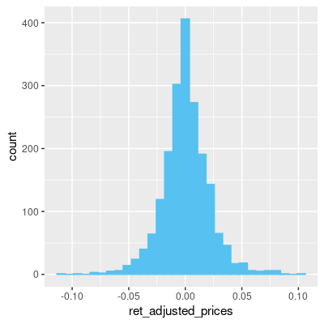

#### Question

17. Utilizando o pacote `yfR` e argumento `freq_data = 'monthly'` em `yf_get`, baixe os dados dos preços **mensais** da Petrobras, ticker = *PETR3.SA*, de 2015 até o dia atual. Com base nos dados importados, crie um histograma dos retornos mensais da ação, adicionando os seguintes itens ao gráfico:
    - título e subtítulo;
    - texto no eixo x e y;
    - caption;
    - tema `theme_light`

#### Solution

    ```
    library(ggplot2)
    library(stringr)

    ticker <- "PETR3.SA"
    df_yf <- yfR::yf_get(ticker, freq_data = 'monthly',
                         first_date = "2015-01-01",
                         last_date = Sys.Date())
    ```

    ```
    ## ── Running yfR for 1 stocks | 2015-01-01 --> 2022-11-23 (2883 days) ──
    ```

    ```
    ## ℹ Downloading data for benchmark ticker ^GSPC
    ```

    ```
    ## ℹ (1/1) Fetching data for PETR3.SA
    ```

    ```
    ## ✔    - found cache file (2015-01-02 --> 2022-11-22)
    ```

    ```
    ## ✔    - got 1961 valid rows (2015-01-02 --> 2022-11-22)
    ```

    ```
    ## ✔    - got 96% of valid prices -- Good job msperlin!
    ```

    ```
    ## ℹ Binding price data
    ```

    ```
    ## ── Diagnostics ───────────────────────────────────
    ```

    ```
    ## ✔ Returned dataframe with 95 rows -- Good job msperlin!
    ```

    ```
    ## ℹ Using 1.0 MB at /tmp/RtmpvTm1wO/yf_cache for 7 cache files
    ```

    ```
    ## ℹ Out of 1 requested tickers, you got 1 (100%)
    ```

    ```
    p <- ggplot(df_yf, aes(x = ret_adjusted_prices)) +
      geom_histogram() +
      labs(
        title = str_glue("Histograma de Retornos Mensais da {ticker}"),
        subtitle = str_glue("Dados entre {min(df_yf$ref_date)} e {max(df_yf$ref_date)}"),
        caption = "Dados do Yahoo Finance",
        x = "Retorno Mensal",
        y = "Frequência"
      ) +
      theme_light()

    p
    ```

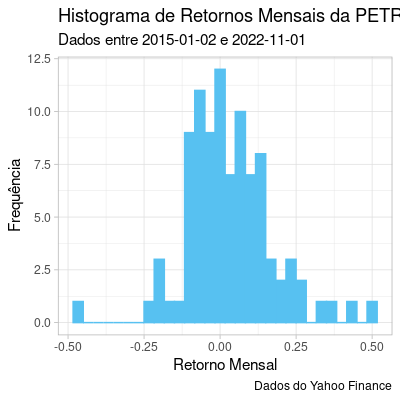

#### Question

18. Pacote `microdatasus`, criado por Raphael Saldanha (rfsaldanha), importa e limpa dados do Sistema de Saúde Único (SUS). No pacote do livro é possível encontrar dados de mortalidade importados pelo `microdatasus` e filtrados para manter apenas algumas colunas da base completa. O arquivo é chamado Exercises-sus-mortality-data.csv e pode ser importado com a função `vdr::data_import`.

    Com base nos dados da coluna `age`, crie um gráfico de **densidade** para a distribuição de idades de falecimento, incluindo os seguintes itens no gráfico:
    - título;
    - texto no eixo x e y;
    - caption;
    - tema `theme_light`

#### Solution

    ```
    library(ggplot2)

    df_sus <- vdr::data_import("Exercises-sus-mortality-data.csv")

    p <- ggplot(df_sus , aes(x = age)) +
      geom_density() +
      labs(
        title = stringr::str_glue("Densidade de Mortalidade para o RS"),
        subtitle = stringr::str_glue("Dados para os anos de 2019 e 2020"),
        caption = "Dados do SUS (importado com microdatasus)",
        x = "Idade de Morte",
        y = "Densidade"
      ) +
      theme_light()

    p
    ```

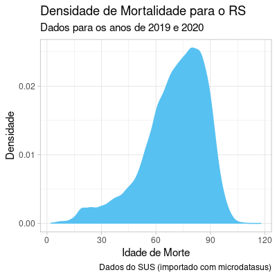

#### Question

19. Para os mesmos dados de mortalidade retirados do SUS, crie um gráfico QQ com a distribuição de idades de falecimento (coluna `age`).

#### Solution

    ```
    library(ggplot2)

    df_sus <- vdr::data_import("Exercises-sus-mortality-data.csv")

    p <- ggplot(df_sus , aes(sample = age)) +
      geom_qq() +
      geom_qq_line()

    p
    ```

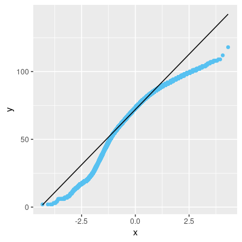

#### Question

20. Considerando novamente os dados de mortalidade do SUS, crie um gráfico de densidade de distribuição, porém separe as linhas do gráfico de acordo com o gênero (Masculino/Feminino). Isto é, queremos uma linha de densidade para o sexo masculino, e outra para o feminino. Dica: remova os casos de SEXO = NA (*Not Available*) antes de criar o gráfico.

#### Solution

    ```
    library(ggplot2)
    library(stringr)

    df_sus <- vdr::data_import("Exercises-sus-mortality-data.csv")

    p <- ggplot(df_sus, aes(x = age, color = SEXO)) +
      geom_density() +
      labs(
        title = str_glue("Densidade de Mortalidade para o RS"),
        subtitle = str_glue("Dados para os anos de 2019 e 2020"),
        caption = "Dados do SUS (importado com microdatasus)",
        x = "Idade de Morte",
        y = "Densidade"
      ) +
      theme_light()

    p
    ```

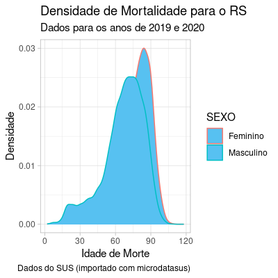

#### Question

21. Repita o exercício anterior, porém use facetas para mostrar as diferentes densidades de mortalidade entre os gêneros masculino e feminino. Dentro da função `facet_wrap`, use argumento `nrow = 2` para empilhar os painéis verticalmente.

#### Solution

    ```
    library(ggplot2)
    library(stringr)

    df_sus <- vdr::data_import("Exercises-sus-mortality-data.csv")

    p <- ggplot(df_sus , aes(x = age)) +
      geom_density() +
      labs(
        title = str_glue("Densidade de Mortalidade para o RS"),
        subtitle = str_glue("Dados para os anos de 2019 e 2020"),
        caption = "Dados do SUS (importado com microdatasus)",
        x = "Idade de Morte",
        y = "Densidade"
      ) +
      theme_light() +
      facet_wrap(~SEXO, nrow = 2)

    p
    ```

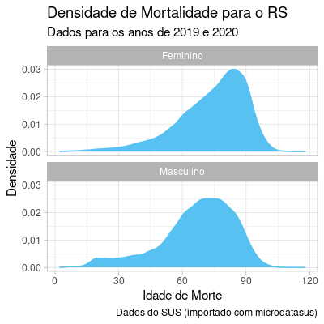

#### Question

22. Considerando novamente os dados do SUS, use o comando `facet_grid` para mostrar as densidades de idade de falecimento quando separando os dados por gênero (coluna SEXO) e escolaridade (coluna ESC). DICA: remova os casos de NA (*Not Available*) encontrados em ambas colunas, SEXO e ESC.

#### Solution

    ```
    library(ggplot2)
    library(stringr)

    df_sus <- vdr::data_import("Exercises-sus-mortality-data.csv")

    p <- ggplot(df_sus , aes(x = age)) +
      geom_density() +
      labs(
        title = str_glue("Densidade de Mortalidade para o RS"),
        subtitle = str_glue("Dados para os anos de 2019 e 2020"),
        caption = "Dados do SUS (importado com microdatasus)",
        x = "Idade de Morte",
        y = "Densidade"
      ) +
      theme_light() +
      facet_grid(ESC~SEXO)

    p
    ```

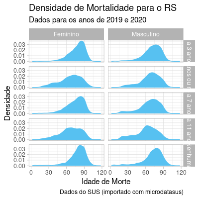

#### Question

23. Crie um gráfico de diagrama (*boxplot*), onde o eixo horizontal é a escolaridade (coluna ESC) e o eixo vertical representa a distribuição dos dados de idade de falecimento, coluna (`age`).

#### Solution

    ```
    library(ggplot2)
    library(stringr)

    df_sus <- vdr::data_import("Exercises-sus-mortality-data.csv")

    p <- ggplot(df_sus , aes(x = ESC, y = age)) +
      geom_boxplot() +
      labs(
        title = str_glue("Distribuição de mortalidade para diferentes escolariedades"),
        subtitle = str_glue("Dados para os anos de 2019 e 2020"),
        caption = "Dados do SUS (importado com microdatasus)",
        x = "Escolaridade",
        y = "Idade de falecimento"
      ) +
      theme_light()

    p
    ```

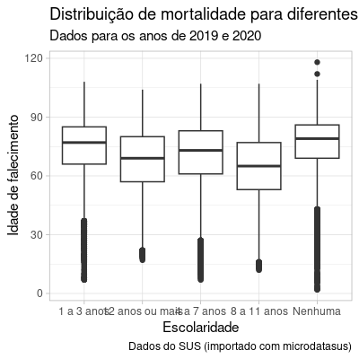

#### Question

24. Utilizando função `geobr::read_country`, baixe os dados do território do Brasil e mostre a área em um novo gráfico.

#### Solution

    ```
    br <- geobr::read_country()
    ```

    ```
    ## Using year 2010
    ```

    ```
    p <- ggplot() +
      geom_sf(data = br)

    p
    ```

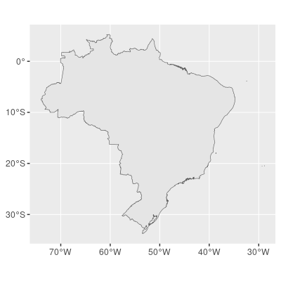

#### Question

25. Utilizando função `geobr::read_indigenous_land`, baixe os dados do território indígena no Brasil e adicione esta camada ao gráfico do Brasil criado anteriormente, com as fronteiras da área indígena representadas na cor vermelha.

#### Solution

    ```
    df_sf <- geobr::read_indigenous_land()
    ```

    ```
    ## Using year 201907
    ```

    ```
    br <- geobr::read_country()
    ```

    ```
    ## Using year 2010
    ```

    ```
    p <- ggplot() +
      geom_sf(data = br) +
      geom_sf(data = df_sf, color = 'red')

    p
    ```

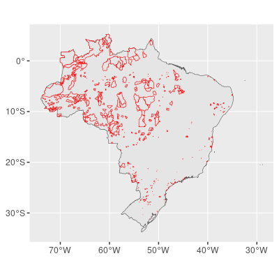

#### Question

26. Utilizando função `geobr::read_state()`, baixe os dados de todos os estados do Brasil e, em um mapa do país, mostre os limites de cada estado na cor azul.

#### Solution

    ```
    df_states <- geobr::read_state(code_state = "all")
    ```

    ```
    ## Using year 2010
    ```

    ```
    ##
      |
      |                                        |   0%
    ```

    ```
    br <- geobr::read_country()
    ```

    ```
    ## Using year 2010
    ```

    ```
    p <- ggplot() +
      geom_sf(data = br) +
      geom_sf(data = df_states,
              color = 'blue')

    p
    ```

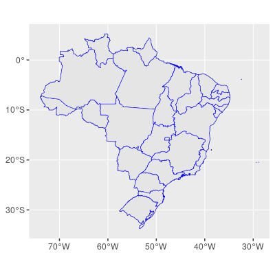

#### Question

27. Utilizando função `geobr::read_state()`, baixe os dados do estado do Rio Grande do Sul e, com os dados disponíveis no arquivo “Chapter07-latlong-cities-brazil.csv” do pacote `vdr`:
    1. mostre as cidades gaúchas como pontos azuis no mapa, ajustando o tamanho e transparência dos pontos para melhor visualização do mapa;
    2. mostre a capital, Porto alegre, como um ponto vermelho com tamanho e intensidade maior.
    3. adicione o texto “PORTO ALEGRE” em preto, acima do ponto de localização da capital.
    4. adicione título e caption para o gráfico

#### Solution

    ```
    df_rs <- geobr::read_state(code_state = "RS")
    ```

    ```
    ## Using year 2010
    ```

    ```
    f_cities <- "Chapter07-latlong-cities-brazil.csv"
    df_cities_rs <- vdr::data_import(f_cities) |>
      dplyr::filter(codigo_uf == 43) # 43 is state of RS

    poa <- df_cities_rs |>
      dplyr::filter(capital == TRUE)

    p <- ggplot() +
      geom_sf(data = df_rs) +
      # etapa 01
      geom_point(data = df_cities_rs,
                 aes(y = latitude, x = longitude),
                 color = 'blue',
                 size = 1,
                 alpha = 0.5) +
      # etapa 02
      geom_point(data = poa,
                 aes(y = latitude, x = longitude),
                 color = 'red',
                 size = 2,
                 alpha = 1) +
      # etapa 03
      geom_text(data = poa,
                 aes(y = latitude, x = longitude,
                     label = "PORTO ALEGRE"),
                 color = 'black',
                 size = 3,
                 alpha = 1,
                nudge_y = 0.25) +
      # etapa 04
      labs(title = "Cidades do Estado do Rio Grande do Sul",
           caption = "Dados do IBGE e pacote vdr")


    p
    ```

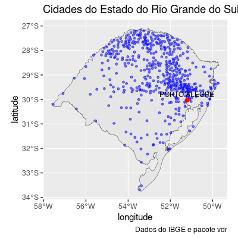

#### Question

28. O código abaixo irá criar um gráfico simples com os preços da ação da empresa Engie (*EGIE.SA*).

    ```
    library(ggplot2)

    df_yf <- yfR::yf_get("EGIE3.SA",
                  first_date = "2018-01-01")
    ```

    ```
    ## ── Running yfR for 1 stocks | 2018-01-01 --> 2022-11-23 (1787 days) ──
    ```

    ```
    ## ℹ Downloading data for benchmark ticker ^GSPC
    ```

    ```
    ## ℹ (1/1) Fetching data for EGIE3.SA
    ```

    ```
    ## ✔    - found cache file (2018-01-02 --> 2022-11-22)
    ```

    ```
    ## ✔    - got 1212 valid rows (2018-01-02 --> 2022-11-22)
    ```

    ```
    ## ✔    - got 96% of valid prices -- Looking good!
    ```

    ```
    ## ℹ Binding price data
    ```

    ```
    ## ── Diagnostics ───────────────────────────────────
    ```

    ```
    ## ✔ Returned dataframe with 1212 rows -- Well done msperlin!
    ```

    ```
    ## ℹ Using 1.0 MB at /tmp/RtmpvTm1wO/yf_cache for 7 cache files
    ```

    ```
    ## ℹ Out of 1 requested tickers, you got 1 (100%)
    ```

    ```
    p <- ggplot(
      df_yf,
      aes(x = ref_date, y = price_adjusted)
    ) + geom_line()
    ```

    Após a execução do código acima, use as ferramentas de programação do R para testar os seguintes temas da figura:
    - `ggplot2::theme_light()`
    - `ggplot2::theme_bw()`
    - `ggplot2::theme_grey()`
    - `ggplot2::theme_minimal()`

    e lembre de adicionar a informação do tema no título da figura.

#### Solution

    ```
    plot_fct <- function(theme_str, p) {

        this_theme <- eval(parse(text = theme_str))
        p <- p +
          this_theme() +
          labs(title = stringr::str_glue("{theme_str}"))

        return(p)
    }

    my_themes <- c(
      "ggplot2::theme_light",
      "ggplot2::theme_bw",
      "ggplot2::theme_grey",
      "ggplot2::theme_minimal"
    )

    l_p <- purrr::map(my_themes, plot_fct, p = p)

    cowplot::plot_grid(plotlist = l_p)
    ```

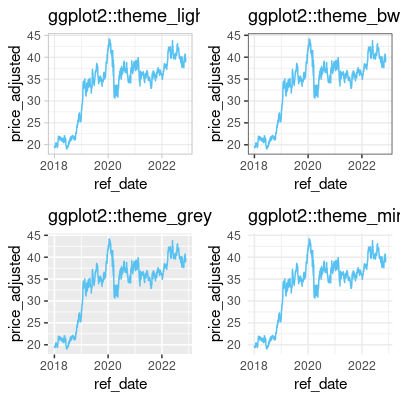

#### Question

29. Considere o gráfico *template* gerado pelo código a seguir:

    ```
    library(ggplot2)

    p <- ggplot(
      yfR::yf_get("USIM5.SA", first_date = "2018-01-01"),
      aes(x = ref_date, y = price_adjusted)
    ) +
      geom_line() +
      labs(subtitle = "SUBTITLE",
           caption = "CAPTION")
    ```

    ```
    ## ── Running yfR for 1 stocks | 2018-01-01 --> 2022-11-23 (1787 days) ──
    ```

    ```
    ## ℹ Downloading data for benchmark ticker ^GSPC
    ```

    ```
    ## ℹ (1/1) Fetching data for USIM5.SA
    ```

    ```
    ## ✔    - found cache file (2018-01-02 --> 2022-11-22)
    ```

    ```
    ## ✔    - got 1212 valid rows (2018-01-02 --> 2022-11-22)
    ```

    ```
    ## ✔    - got 96% of valid prices -- Youre doing good!
    ```

    ```
    ## ℹ Binding price data
    ```

    ```
    ## ── Diagnostics ───────────────────────────────────
    ```

    ```
    ## ✔ Returned dataframe with 1212 rows -- You got it msperlin!
    ```

    ```
    ## ℹ Using 1.0 MB at /tmp/RtmpvTm1wO/yf_cache for 7 cache files
    ```

    ```
    ## ℹ Out of 1 requested tickers, you got 1 (100%)
    ```

    Pacote `hrbrthemes` oferece uma grande variedade de temas adicionais a serem utilizados em um gráfico do `ggplot2`. Todas funções de tema possum um padrão bem distinto, onde o nome da função inicia com o texto `theme_`. Baseado nesta informação e também no uso da função `ls`, podemos descobrir o nome de todas as funções de tema do `hrbrthemes` com o código abaixo:

    ```
    library(hrbrthemes)

    all_fcts <- ls("package:hrbrthemes")

    idx <- all_fcts |>
      stringr::str_which("theme_")

    theme_fcts <- all_fcts[idx]
    ```

    Com base no código anterior:
    1. use as ferramentas de programação do R para, de forma automática, aplicar todos os temas anteriores para o gráfico gerado acima.
    2. agrege todos os gráfico em um único arquivo com função `cowplot::plot_grid`
    3. salve a figura resultante como `hrbrthemes-demo.png`, pasta documentos (atalho com `~`). Defina o tamanho da figura como height = 20cm e width = 30cm. DICA: Caso a figura gravada sair com fundo transparente, abra-a em um navegador da web, tal como o Chrome ou firefox.

#### Solution

    ```
    library(hrbrthemes)
    library(ggplot2)

    plot_fct <- function(theme_str, p) {

        this_theme <- eval(parse(text = theme_str))
        p <- p +
          this_theme() +
          labs(title = stringr::str_glue("{theme_str}"))

        return(p)
    }

    all_fcts <- ls("package:hrbrthemes")

    idx <- all_fcts |>
      stringr::str_which("theme_")

    theme_fcts <- all_fcts[idx]

    # fina all theme fcts
    my_themes <- theme_fcts

    l_p <- purrr::map(my_themes, plot_fct, p = p)

    p_grid <- cowplot::plot_grid(plotlist = l_p)

    p_grid
    ```

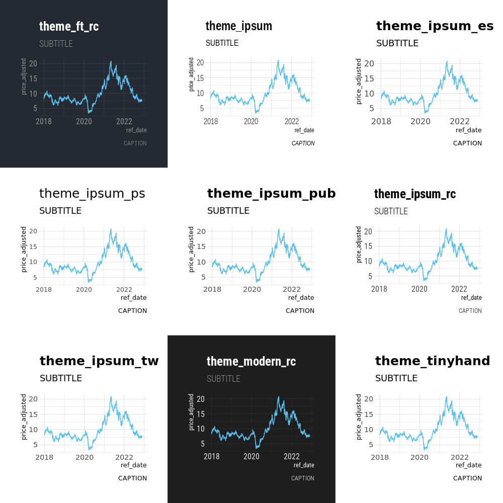

    ```
    ggsave("~/hrbrthemes-demo.png", p_grid, height = 20, width = 30, units = "cm")
    ```

#### Question

30. Considere o gráfico criado de barras criado com o código abaixo:

    ```
    library(ggplot2)

    tickers <- c("PETR3.SA", "ITSA3.SA",
                 "GRND3.SA", "GGBR3.SA",
                 "EGIE3.SA", "USIM5.SA")

    df_yf <- yfR::yf_get(tickers,
                         "2020-01-01")
    ```

    ```
    ## ── Running yfR for 6 stocks | 2020-01-01 --> 2022-11-23 (1057 days) ──
    ```

    ```
    ## ℹ Downloading data for benchmark ticker ^GSPC
    ```

    ```
    ## ℹ (1/6) Fetching data for EGIE3.SA
    ```

    ```
    ## ✔    - found cache file (2018-01-02 --> 2022-11-22)
    ```

    ```
    ## ✔    - got 718 valid rows (2020-01-02 --> 2022-11-22)
    ```

    ```
    ## ✔    - got 96% of valid prices -- All OK!
    ```

    ```
    ## ℹ (2/6) Fetching data for GGBR3.SA
    ```

    ```
    ## ✔    - found cache file (2020-01-02 --> 2022-11-22)
    ```

    ```
    ## ✔    - got 718 valid rows (2020-01-02 --> 2022-11-22)
    ```

    ```
    ## ✔    - got 96% of valid prices -- Good job msperlin!
    ```

    ```
    ## ℹ (3/6) Fetching data for GRND3.SA
    ```

    ```
    ## ✔    - found cache file (2015-01-02 --> 2022-11-22)
    ```

    ```
    ## ✔    - got 718 valid rows (2020-01-02 --> 2022-11-22)
    ```

    ```
    ## ✔    - got 96% of valid prices -- Time for some tea?
    ```

    ```
    ## ℹ (4/6) Fetching data for ITSA3.SA
    ```

    ```
    ## ✔    - found cache file (2020-01-02 --> 2022-11-22)
    ```

    ```
    ## ✔    - got 718 valid rows (2020-01-02 --> 2022-11-22)
    ```

    ```
    ## ✔    - got 96% of valid prices -- You got it msperlin!
    ```

    ```
    ## ℹ (5/6) Fetching data for PETR3.SA
    ```

    ```
    ## ✔    - found cache file (2015-01-02 --> 2022-11-22)
    ```

    ```
    ## ✔    - got 718 valid rows (2020-01-02 --> 2022-11-22)
    ```

    ```
    ## ✔    - got 96% of valid prices -- All OK!
    ```

    ```
    ## ℹ (6/6) Fetching data for USIM5.SA
    ```

    ```
    ## ✔    - found cache file (2018-01-02 --> 2022-11-22)
    ```

    ```
    ## ✔    - got 718 valid rows (2020-01-02 --> 2022-11-22)
    ```

    ```
    ## ✔    - got 96% of valid prices -- All OK!
    ```

    ```
    ## ℹ Binding price data
    ```

    ```
    ## ── Diagnostics ───────────────────────────────────
    ```

    ```
    ## ✔ Returned dataframe with 4308 rows -- Looking good!
    ```

    ```
    ## ℹ Using 1.0 MB at /tmp/RtmpvTm1wO/yf_cache for 7 cache files
    ```

    ```
    ## ℹ Out of 6 requested tickers, you got 6 (100%)
    ```

    ```
    df_tab <- df_yf |>
      dplyr::group_by(ticker) |>
      dplyr::summarise(
        total_ret = dplyr::last(cumret_adjusted_prices) - 1
        ) |>
      dplyr::arrange(total_ret)

    p <- ggplot(df_tab, aes(x = reorder(ticker, total_ret),
                              y = total_ret,
                              fill = total_ret)) +
      geom_col(color = "white") +
      theme_minimal() +
      coord_flip() +
      labs(title = stringr::str_glue(
        "Performance de {length(tickers)} Ações Selecionadas"
        ),
           y = "Retorno Total",
           x = "Ticker")
    ```

#### Solution

    ```
    library(ggplot2)

    plot_fct <- function(theme_str, palette, p) {

        this_theme <- eval(parse(text = theme_str))

        p <- p +
          this_theme() +
          labs(
            subtitle = stringr::str_glue(
            "{theme_str} | {palette}"
            ),
            title = "Demonstração") +
          colorspace::scale_fill_binned_diverging(palette)

        return(p)
    }

    theme_fcts <- c(
      "ggplot2::theme_light",
      "hrbrthemes::theme_ipsum_es",
      "ggtech::theme_airbnb_fancy"
      )

    palettes <- c(
      "Red-Green",
      "Green-Brown",
      "Tropic"
    )

    df_grid <- tidyr::expand_grid(
      theme_fcts,
      palettes
    )

    l_args <- list(
      theme_str = df_grid$theme_fcts,
      palette = df_grid$palettes
    )

    l_p <- purrr::pmap(.l = l_args, .f = plot_fct, p = p)

    p_grid <- cowplot::plot_grid(plotlist = l_p)

    p_grid
    ```

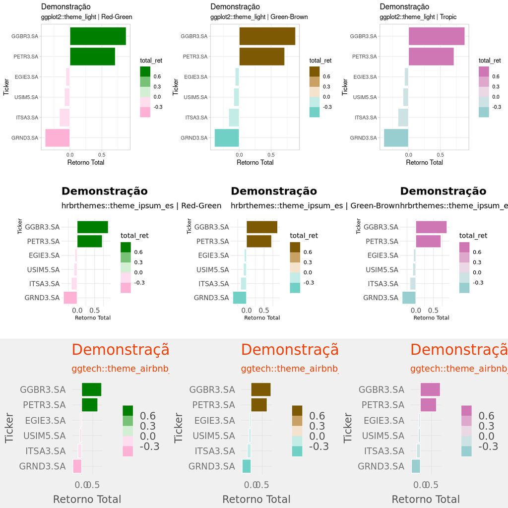

    ```
    ggsave("~/themes-and-palettes-demo.png", p_grid, height = 40, width = 60, units = "cm")
    ```